# Airbnb visualization

By Danilo Motta

Lets analyse Airbnb data samples to find business opportunities, improve costumers experience and (maybe) increase profitability.

First lets start with some data exploration and visualization.

The data used in this project was made availabe online by [Inside Airbnb](http://insideairbnb.com/get-the-data.html).

```python
import pandas as pd
import matplotlib.pyplot as plt
import seaborn as sns

pd.set_option('display.max_rows', 500)
pd.set_option('display.max_columns', 500)
%matplotlib inline

import geoviews as gv
gv.extension('bokeh')
```

### Loading data

```python
tiles = gv.tile_sources.Wikipedia.opts(width=900, height=500)
```

```python
df = pd.read_csv('../sample_data/sample_data3.csv',
                 usecols=['city','state','latitude','longitude','review_scores_rating',
                         'review_scores_accuracy','review_scores_cleanliness','review_scores_checkin',
                         'review_scores_communication','review_scores_location','review_scores_value'])
```

```python
cities = ['montreal', 'rio_de_janeiro', 'stockholm']
```

```python
df.head()
```

|  | city | state | latitude | longitude | review_scores_rating | review_scores_accuracy | review_scores_cleanliness | review_scores_checkin | review_scores_communication | review_scores_location | review_scores_value |
| --- | --- | --- | --- | --- | --- | --- | --- | --- | --- | --- | --- |
| 0 | stockholm | Stockholms län | 59.313306 | 18.074136 | 93.0 | 10.0 | 8.0 | 10.0 | 10.0 | 10.0 | 9.0 |
| 1 | stockholm | Stockholms län | 59.345852 | 18.067252 | 0.0 | 0.0 | 0.0 | 0.0 | 0.0 | 0.0 | 0.0 |
| 2 | stockholm | Stockholms län | 59.344721 | 18.029013 | 0.0 | 0.0 | 0.0 | 0.0 | 0.0 | 0.0 | 0.0 |
| 3 | stockholm | Stockholms län | 59.314402 | 18.083113 | 91.0 | 9.0 | 9.0 | 9.0 | 10.0 | 10.0 | 9.0 |
| 4 | stockholm | Stockholms län | 59.336792 | 17.976820 | 90.0 | 7.0 | 7.0 | 9.0 | 9.0 | 7.0 | 7.0 |

### Review distribution

Lets check the reviews distribution to compare the selected cities.

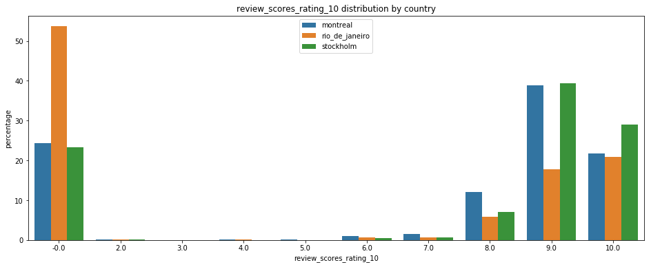

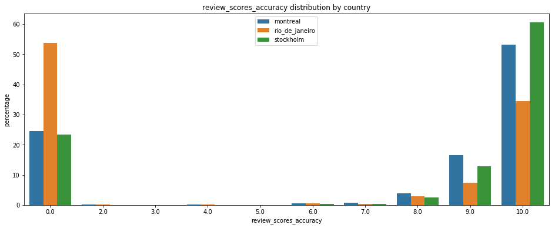

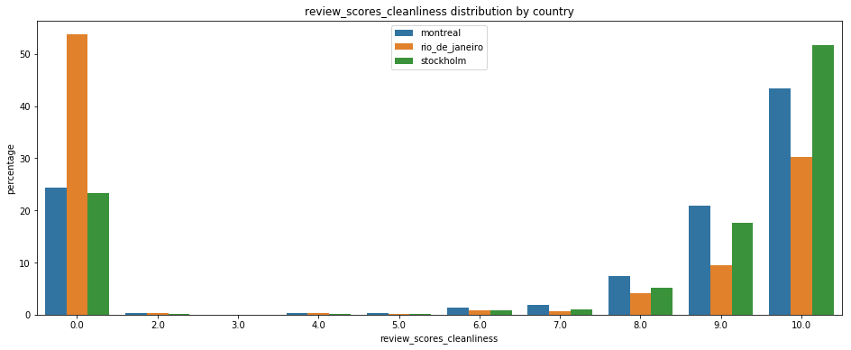

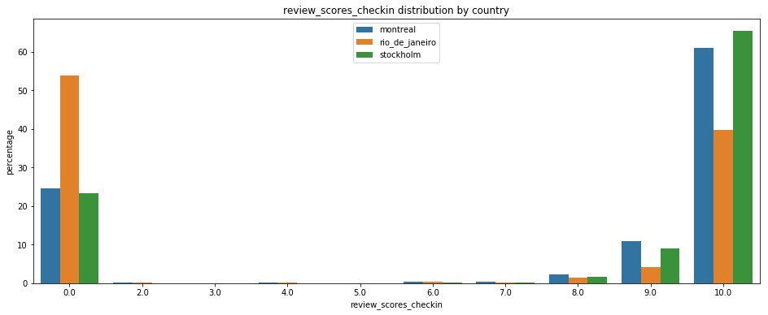

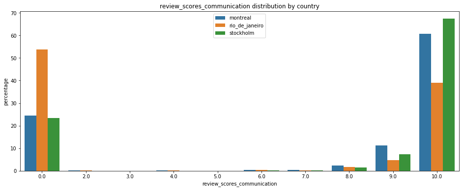

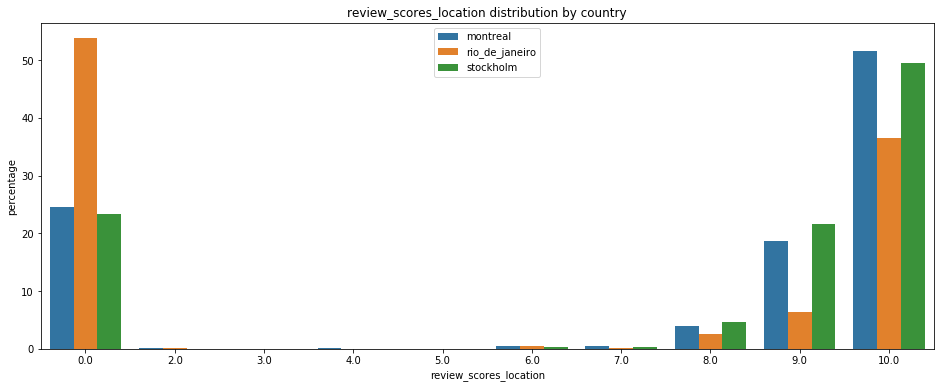

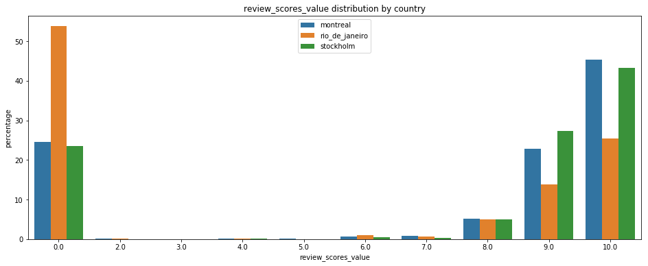

```python
df['review_scores_rating_10'] = df.review_scores_rating // 10

rev_cols = ['review_scores_rating_10',
            'review_scores_accuracy',
            'review_scores_cleanliness',
            'review_scores_checkin',
            'review_scores_communication',
            'review_scores_location',
            'review_scores_value']

for col in rev_cols:
    counts = df.groupby(['city'])[col] \
                .value_counts(normalize=True) \
                .rename('percentage') \
                .mul(100) \
                .reset_index() \
                .sort_values('percentage')

    plt.figure(figsize=(16, 6))
    plt.title(col+' distribution by country')
    sns.barplot(x=col, y="percentage", hue='city', data=counts, hue_order=cities)
    plt.legend(loc='upper center')

df.drop('review_scores_rating_10', axis=1, inplace=True)
```

From the distributions we can notice that Montreal and Stockholm have better reviews (in percentage) then Rio de Janeiro.

### Geospacial visualization

As we have the benefit of geospacial data, would be useful to get a glimpse of the data behavior over maps to maybe find some patterns.

```python
import geopandas as gpd

def read_geo(path):
    f = gpd.read_file(path)
    return f

path = '../sample_data/'
geo = 'geo/'

def read_geos(countries):
    data = {}
    for city in cities:
        file = path + geo + city + '_airbnb.geojson'
        data[city] = gpd.read_file(file)
    return data

geo_df = read_geos(cities)
```

```python
gdf = gpd.GeoDataFrame()
for city in cities:
    geo_df[city] = geo_df[city].to_crs({'init': 'epsg:4326'})
    tmp = gpd.GeoDataFrame(df[df.city==city],
                              geometry=gpd.points_from_xy(df[df.city==city].longitude,
                                                          df[df.city==city].latitude),
                              crs={'init' :'epsg:4326'})
    sjoined_listings = gpd.sjoin(tmp, geo_df[city], op='within')
    gdf = gdf.append(sjoined_listings)
```

```python
for city in cities:
    tmp = gdf[gdf.city==city].groupby('index_right').mean().reset_index()
    tmp['num_reviews'] = gdf[gdf.city==city].groupby('index_right').state.size()
    geo_df[city] = geo_df[city].reset_index().merge(tmp, left_on='index', right_on='index_right', how='outer')
```

```python
def make_poly(df, city, feat, title):
    return gv.Polygons(df[city], vdims=['neighbourhood', feat], label=title).opts(
             color_index=feat, colorbar=True, padding=0.1, tools=['hover'],width=400, height=400,alpha=0.7,
             xaxis=None, yaxis=None)
```

```python
feats = ['review_scores_rating',
         'review_scores_accuracy',
         'review_scores_cleanliness',
         'review_scores_checkin',
         'review_scores_communication',
         'review_scores_location',
         'review_scores_value',
         'num_reviews']
```

```python
# https://github.com/holoviz/panel/issues/808
import panel as pn
import geoviews.tile_sources as gvts
from functools import partial

sel_stock = pn.widgets.Select(options=feats)

@pn.depends(basemap=sel_stock)
def stock_view(basemap):
    return tiles*make_poly(geo_df, 'stockholm', basemap, 'Stockholm vis')

pn.Column(sel_stock, stock_view)
```

[interactive chart not shown]

```python
sel_montreal = pn.widgets.Select(options=feats)

@pn.depends(basemap=sel_montreal)
def mon_view(basemap):
    return tiles*make_poly(geo_df, 'montreal', basemap, 'Montreal vis')

pn.Column(sel_montreal, mon_view)
```

[interactive chart not shown]

```python
sel_rio = pn.widgets.Select(options=feats)

@pn.depends(basemap=sel_rio)
def rio_view(basemap):
    return tiles*make_poly(geo_df, 'rio_de_janeiro', basemap, 'Rio de Janeiro vis')

pn.Column(sel_rio, rio_view)
```

[interactive chart not shown]

### CONCLUSIONS

On first thought, one could think that one region has better reviews because of the location where better neighborhoods have better reviews. Our visualizations tell other history: high review score areas are sparsely distributed!

Apart from Stockholm where most regions have similar scores, in the other two cities we can observe high scores in neighborhoods surrounded by low score regions.

In Rio, this can be seen clearly in at least three regions: Grumari, Campo dos Afonsos and Turiaçu. The same behavior can be observed in Montreal at Senneville.

##### By visualizing the data we can conclude that we need to look further than the simple good/bad regions to find why some reviews are better than others.